# Exploratory Data Analysis, Uncertainty, Test & Roll

GEORGE KNOX

Computer Lab 1

# Introduction: Exploratory Data Analysis and prep

In the first part, we go slowly over loading packages, loading a data set. Then we discuss uncertainty. Estimates have uncertainty. Here we look at the mean and its sampling distribution for a continuous and a binary scaled variables. We calculate the mean and its standard error using the normal approximation and using the bootstrap.

## Installing the packages

```r
# Begin by deleting any previously defined variables
rm(list = ls())

# Let's install packages a number of useful packages.
# To make things easy, the following snippet of code will download
# and install everything you'll need.
# But for future reference, remember that to install a package
# you only have to type
# > install.packages("<packagename>")
# And then you can load it with
# > library(lib)

packages <- c("devtools"
  ,"randomForest"
  ,"rpart" # decision tree
  ,"rpart.plot" # enhanced tree plots
  ,"ROCR"
  ,"Hmisc"
  ,"corrplot"
  ,"texreg"
  ,"glmnet"
  ,"reshape2"
  ,"knitr"
  ,"xtable"
  ,"lars"
  ,"ggplot2"
  ,"matrixStats"
  ,"plyr"
  ,"stargazer"
  ,"foreign"
  ,"data.table"
  ,"VGAM"
  ,"dplyr"
  ,"doParallel")


#not_installed <- !packages %in% installed.packages()
#if (any(not_installed)) install.packages(packages[not_installed])
#lapply(packages,require,character.only=TRUE)

library(dplyr)
```

## Loading the data

Set your working directory; write the path where the folder with the data is located. What I do is have a directory with the R notebooks (“R notebooks/RFM & logistic”), where this .rmd file is saved. Then within that I have a folder where the data is (“R notebooks/RFM & logistic/data”). Note you have do a forward slash “/” not backslash. We are going to use data from eBeer which we mentioned in lecture.

**Note you have to close the notebook if you want to rerun the code to generate the notebook**

```r
# set your working directory
# write the path where the folder containing the files is located
# setwd("/Users/munyikz/Documents/tutorial")
setwd("/Users/gknox/Dropbox/Customer Analytics/R notebooks/RFM & logistic")

ebeer<-read.csv('data/ebeer.csv')

# set working directory as wherever this .rmd file is saved
# Note: comment this line out below if you want to knit the full doc.

getwd()
```

```
## [1] "C:/Users/gknox/Dropbox/Customer Analytics/R notebooks/RFM & logistic"
```

Set the seed so that random draws are the same for everyone. This is important!

```r
set.seed(19312)
```

## Inspecting the data

Let’s take a look at the dataset: how many observations, how many variables?

```r
dim(ebeer)
```

```
## [1] 9964   11
```

```r
#install.packages("kableExtra")
#library(kableExtra)
```

What do the first observations look like?

```r
head(ebeer)
```

```
##   ï..acctnum gender  R  F     M firstpur age_class single student mailing
## 1      10001      1 30 10  35.7       50         3      1       1       1
## 2      10005      0 16  1 149.0       16         0      0       1       1
## 3      10010      0 12  1 123.0       12         0      1       0       1
## 4      10011      0  6  2 147.0        8         0      1       1       1
## 5      10014      1  6  3  96.0       18         0      0       1       1
## 6      10020      0 12  2 150.5       14         0      1       1       1
##   respmail
## 1        0
## 2        0
## 3        0
## 4        0
## 5        1
## 6        0
```

```r
#ebeer %>%
#  kbl() %>%
#  kable_styling()
```

We have

Account number Gender (1=male) time since last purchase (Recencey) total number of purchases (Frequency) euro’s average transaction (M) Time since first purchase age class (0-8) customer is single customer is student mailing received response to mailing

How about summary statistics about the variables?

```r
summary(ebeer)
```

```
##    ï..acctnum        gender             R               F
##  Min.   :10001   Min.   :0.0000   Min.   : 2.00   Min.   : 1.000
##  1st Qu.:22351   1st Qu.:0.0000   1st Qu.: 8.00   1st Qu.: 1.000
##  Median :34888   Median :0.0000   Median :12.00   Median : 2.000
##  Mean   :34865   Mean   :0.2995   Mean   :13.23   Mean   : 3.893
##  3rd Qu.:47525   3rd Qu.:1.0000   3rd Qu.:16.00   3rd Qu.: 6.000
##  Max.   :59993   Max.   :1.0000   Max.   :36.00   Max.   :12.000
##
##        M             firstpur       age_class          single
##  Min.   : 15.00   Min.   : 2.00   Min.   :0.0000   Min.   :0.0000
##  1st Qu.: 33.83   1st Qu.:12.00   1st Qu.:0.0000   1st Qu.:0.0000
##  Median : 63.00   Median :20.00   Median :1.0000   Median :0.0000
##  Mean   : 91.99   Mean   :26.48   Mean   :0.8509   Mean   :0.3054
##  3rd Qu.:131.50   3rd Qu.:36.00   3rd Qu.:1.0000   3rd Qu.:1.0000
##  Max.   :314.00   Max.   :99.00   Max.   :8.0000   Max.   :1.0000
##
##     student          mailing         respmail
##  Min.   :0.0000   Min.   :0.000   Min.   :0.000
##  1st Qu.:0.0000   1st Qu.:0.000   1st Qu.:0.000
##  Median :1.0000   Median :0.000   Median :0.000
##  Mean   :0.5295   Mean   :0.497   Mean   :0.124
##  3rd Qu.:1.0000   3rd Qu.:1.000   3rd Qu.:0.000
##  Max.   :1.0000   Max.   :1.000   Max.   :1.000
##                                   NA's   :5012
```

Let’s take a look at the variable monetary value. This is the average amount per transaction spent by customer. I’m going to refer to it as the monetary value. Here’s its histogram.

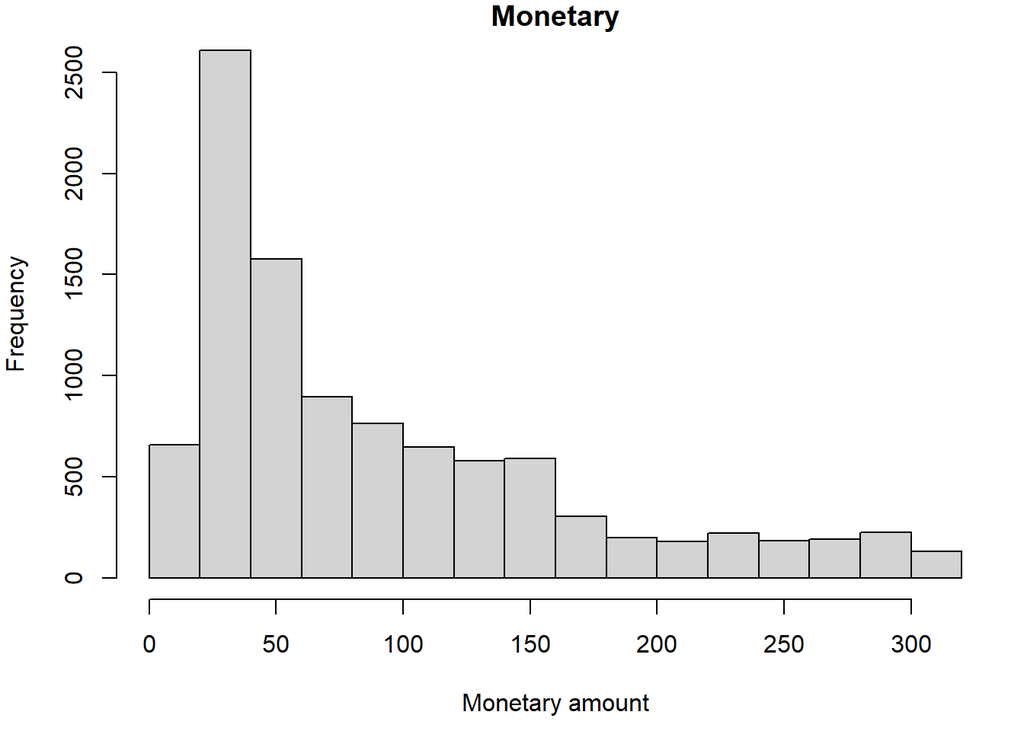

```r
par(mai=c(.9,.8,.2,.2))
hist(ebeer$M, main="Monetary", xlab="Monetary amount")
```

How does average amount spent (monetary) and its standard deviation vary by whether customers responded to the mailing?

```r
ebeer %>%
  group_by(respmail) %>% summarize(mean=mean(M), sd=sd(M), n=n())
```

```
## # A tibble: 3 x 4
##   respmail  mean    sd     n
##      <int> <dbl> <dbl> <int>
## 1        0  98.7  77.0  4336
## 2        1  42.2  26.9   616
## 3       NA  92.3  75.9  5012
```

The above was done using pipes, “%>%”. In general, there are many different ways to compute something in R. (for more info on using pipes: https://www.datacamp.com/community/tutorials/pipe-r-tutorial#howto) You can use any method that works for you.

### Comprehension Check

> *Do you see how respmail has a lot of NA’s? What’s going on there? Does it make sense?*

> [DISCUSS HERE]

# Uncertainty

## Classical Uncertainty

What is the mean monetary value, its variance, and standard error?

Remember the sample mean is:
$$\bar{x} = \frac{1}{n} \sum_{i=1}^{n} x_i$$
And the variance of it is:
$$var(\bar{x}) = var \left( \frac{1}{n} \sum_{i=1}^{n} x_i \right) = \frac{1}{n^2} \sum_{i=1}^{n} var(x_i) = \frac{\sigma^2}{n}$$
where $\sigma^2 = \frac{1}{n-1}\sum_{i=1}^{n} (x_i - \bar{x})^2$ is the variance. The variance goes inside the parentheses because we assume each customer is independent. And the standard error is $se(\bar{x}) = \frac{\sigma}{\sqrt{n}}$. (I’m ignoring finite sample adjustment here.)

```r
nrow(ebeer)  # number of obs.
```

```
## [1] 9964
```

```r
xbar <- mean(ebeer$M) #sample mean
xbse <-  sqrt(var(ebeer$M)/nrow(ebeer)) # sample standard error

xbar
```

```
## [1] 91.99312
```

```r
xbse
```

```
## [1] 0.755848
```

What is the sampling distribution of the mean? If we were able to get a new sample from the same data-generating process what would it be? According to the central limit theorem, the distribution is normal, $\bar{x} \sim N(\bar{x}, var(\bar{x}))$. This distribution below:

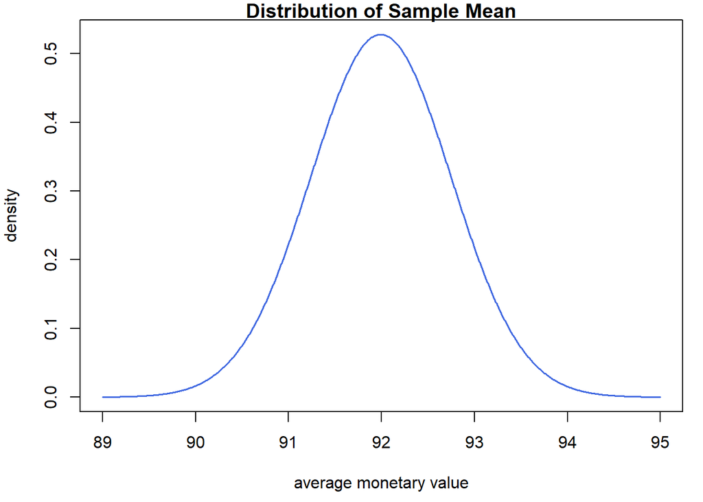

```r
xx <- seq(89,95,length=1000)

par(mai=c(.9,.8,.2,.2))
plot(xx, dnorm(xx, xbar, xbse),main="Distribution of Sample Mean", type="l", col="royalblue", lwd=1.5,
     xlab="average monetary value", ylab="density")
```

When we want to plot over a set of points, `seq(start,end,# points)` is a usefule command that creates a number of points from start to end.

You can create a 95% confidence interval by cutting off the left and right 2.5% of the distribution. Since the distribution is normal, we use the `qnorm()` function, which computes quantiles of the normal distribution.

```r
qnorm(c(0.025, 0.975), mean=xbar, sd=xbse)
```

```
## [1] 90.51169 93.47456
```

Another way to compute the distribution is using the bootstrap. The idea is to resample your data *with replacement*, calculating the statistic each time, e.g., $\bar{x}_1, \bar{x}_2, \dots \bar{x}_B$ and using that to calculate the distribution of the statistic.

```r
# nonparametric bootstrap
B <- 10000 # number of bootstrap samples
mub <- c() # where we are going to collect the mean
set.seed(19312) # setting seed right before sampling
for (b in 1:B){
  samp_b = sample.int(nrow(ebeer), replace=TRUE) # sample with replacement
  mub <- c(mub, mean(ebeer$M[samp_b])) # store the mean of the sample
}

head(mub)  # the mean of the first few bootstrap samples
```

```
## [1] 91.34017 90.78494 91.23552 91.21582 92.91705 92.21848
```

```r
sd(mub) # standard deviation (compare with standard error xbse calculated above)
```

```
## [1] 0.7560679
```

```r
xbse
```

```
## [1] 0.755848
```

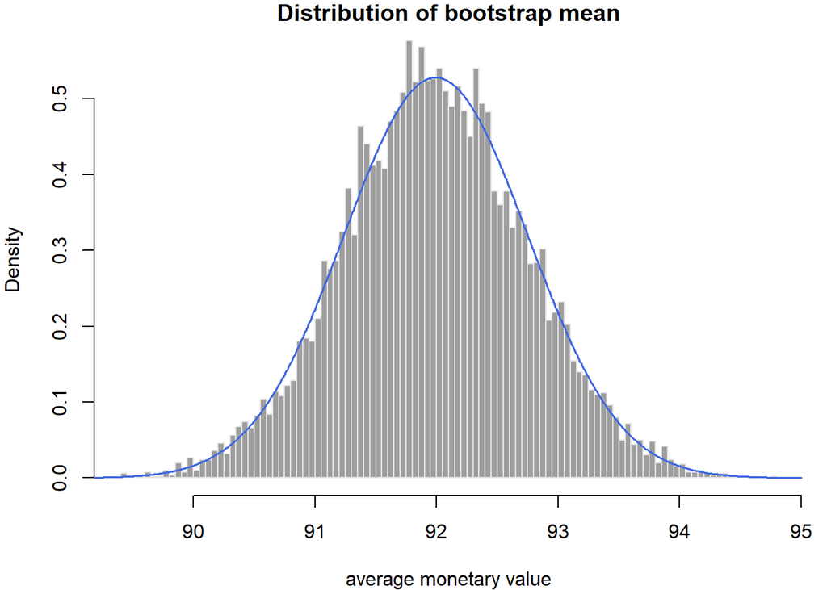

```r
par(mai=c(.8,.8,.2,.2))
hist(mub, main="Distribution of bootstrap mean", xlab="average monetary value", breaks = 100,
     col=8, border="grey90", freq=FALSE)
lines(xx, dnorm(xx, xbar, xbse), col="royalblue", lwd=1.5)
```

Compare the standard errors from the normal approximation and the bootstrap sample. You can create a 95% confidence interval around the mean using the standard error from the bootstrap.

```r
qnorm(c(0.025, 0.975), mean=mean(mub), sd=sd(mub))
```

```
## [1] 90.50748 93.47122
```

```r
sort(samp_b)[1:10]
```

```
##  [1] 1 1 3 4 5 6 8 8 9 9
```

## Bayesian updating

### Prior

#### Beta

The prior represents our beliefs before the seeing the data: could be from past experience or it could be noninformative (flat or diffuse). Here we use a beta distribution: $p$ comes from a common beta distribution where $a$ and $b$ are parameters.
$$f(p | a,b) \propto p^{a-1} (1-p)^{b-1}, \qquad a>0, b>0$$
The mean of the beta distribution is $E[p|a,b]=\frac{a}{a+b}$. Here are some of the [shapes](https://shiny.stat.ncsu.edu/bjreich/Beta_PDF/) the beta distribution can take on.

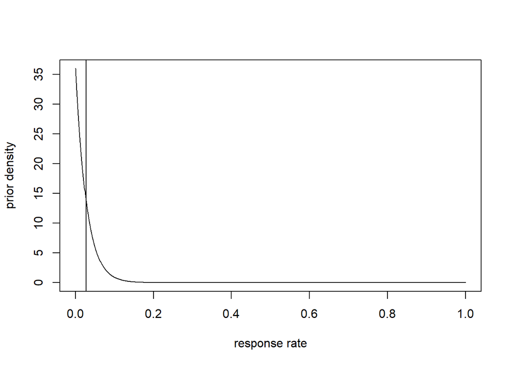

```r
xx=seq(0,1,length=1000)

prior_a = 1
prior_b = 36

plot(xx, y=dbeta(xx, shape1=prior_a, shape2 = prior_b),
     type="l", col="black", xlab="response rate", ylab="prior density")
abline(v=prior_a/(prior_a+prior_b))
```

### Comprehension Check

> *How can you change the above distribution to be a flat, noninformative prior?*

> [DISCUSS HERE]

#### Normal

If the dependent variable is continuous, then we use a normal prior. For example, I would like to know what the mean time-on-site is for the A group and the B group from an A/B test.

Before I saw this data, I knew nothing about how long people might spend on this website. They might stay for 5 seconds or they might stay for 5 hours.

Formally, I can describe my prior beliefs with a *prior distribution*:
$$\textrm{mean time-on-site for group} \sim N(0, 100^2)$$

Here is the picture:

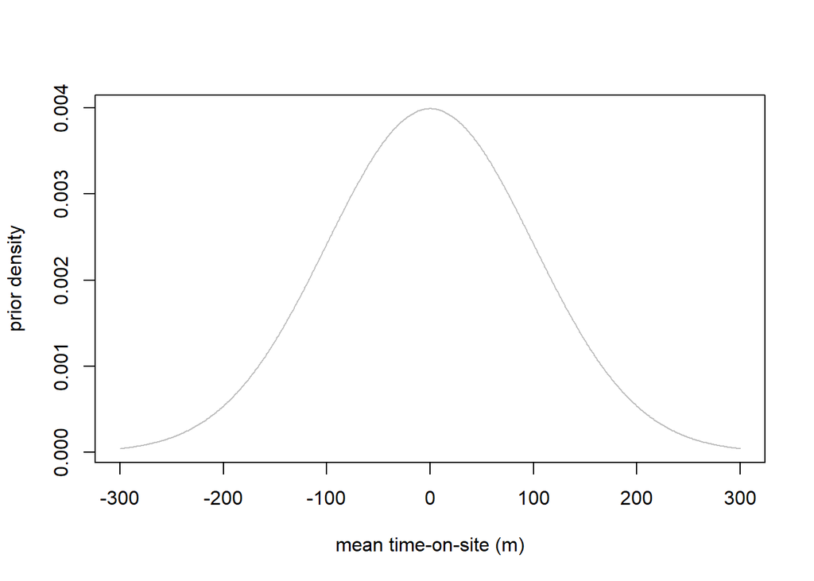

Note the range is from -300 to +300: very big. In other words, we have very little precision.

### Comprehension Check

> *How could you change the above distribution so that you were pretty certain that the average time on site is 2 and 8 minutes?*

> [DISCUSS HERE]

### Posterior

Bayes rule tells you how you should update your beliefs after you see some data.

$$\textrm{posterior} \propto \textrm{likelihood} \times \textrm{prior}$$

#### Beta

We have data from the test below

```r
n = 5000 # number in test sample
s = 175 # number of responses
c = 1.5 # cost per mailing
m = 50 # profit if respond
```

The posterior mean is beta with parameters $a+s$ and $b+n-s$. We can see this visually, along with the breakeven response probability. We can calculate the probability that the posterior is above the breakeven by drawing from a beta distribution with above parameters.

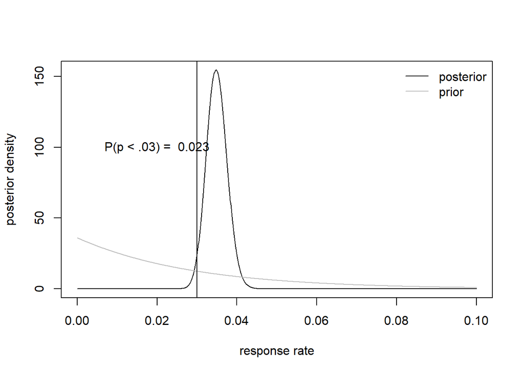

```r
brk = c/m
B = 10000 # number draws from distribution

prior_a = 1
prior_b = 36
post_a= prior_a + s
post_b = prior_b + n - s

xx=seq(0,.1,length=1000)

plot(xx, y=dbeta(xx, shape1=post_a, shape2 = post_b),
     type="l", col="black", xlab="response rate", ylab="posterior density")

plot(xx, y=dbeta(xx, shape1=post_a, shape2 = post_b),
     type="l", col="black", xlab="response rate", ylab="posterior density")
lines(xx, y=dbeta(xx, shape1=prior_a, shape2 = prior_b), type="l", col="gray")
abline(v=brk)
legend("topright", col=c("black", "gray"), legend=c("posterior", "prior"), bty="n", lty=1)
set.seed(19312)
post_draws<-rbeta(B,post_a,post_b)
prob = sum(post_draws<brk)/B
text(x = .02,y= 100, paste("P(p < .03) = ", round(prob,3) ))
```

#### Normal

The data from an A/B test comparing the time users spend on your website for two versions of the homepage is in the data frame `test_data`. A summary of the data looks like this:

```
##   group time_on_site
## 1     A    4.9195005
## 2     A    0.8337443
## 3     A    7.7680014
## 4     A    5.6305779
## 5     A    8.4719249
## 6     A    1.7573413
```

Here it is by group

```r
test_data %>%
  group_by(group) %>% summarize(mean=mean(time_on_site), sd=sd(time_on_site), n=n())
```

```
## # A tibble: 2 x 4
##   group  mean    sd     n
##   <chr> <dbl> <dbl> <int>
## 1 A      5.40  1.97   500
## 2 B      5.44  2.11   500
```

It looks like the B version keeps users on the site a bit longer, but how sure are we that B produces longer visits on average? We’ve only seen 500 visitors in each group.

Then Bayes rule tells us that the posterior distribution for mean time-on-site for each group should be:
$$\textrm{mean time-on-site (m)} \sim \mathcal{N}\left(\mu, \sigma^2\right)$$
where

```r
n_A <- sum(test_data$group=="A") # obs for A
n_B <- sum(test_data$group=="B") # obs for B
s <- sd(test_data$time_on_site) # standard deviation of data (approx)

# Posterior standard deviation follows this formula
post_sd_A <- (1/100^2 + n_A/s^2)^-(1/2)
post_sd_B <- (1/100^2 + n_B/s^2)^-(1/2)

# sample mean
ybar_A<-mean(test_data[test_data$group=="A", "time_on_site"])
ybar_B<-mean(test_data[test_data$group=="B", "time_on_site"])

# Posterior mean is just the mean for each group,
post_mean_A <- post_sd_A^2*(0/100^2 + n_A *ybar_A / s^2)
post_mean_B <- post_sd_B^2*(0/100^2 + n_B *ybar_B / s^2)
```

Note that $\bar{y}_A \approx E[m_A]$ because the prior is so flat.  
We can plot the posteriors.

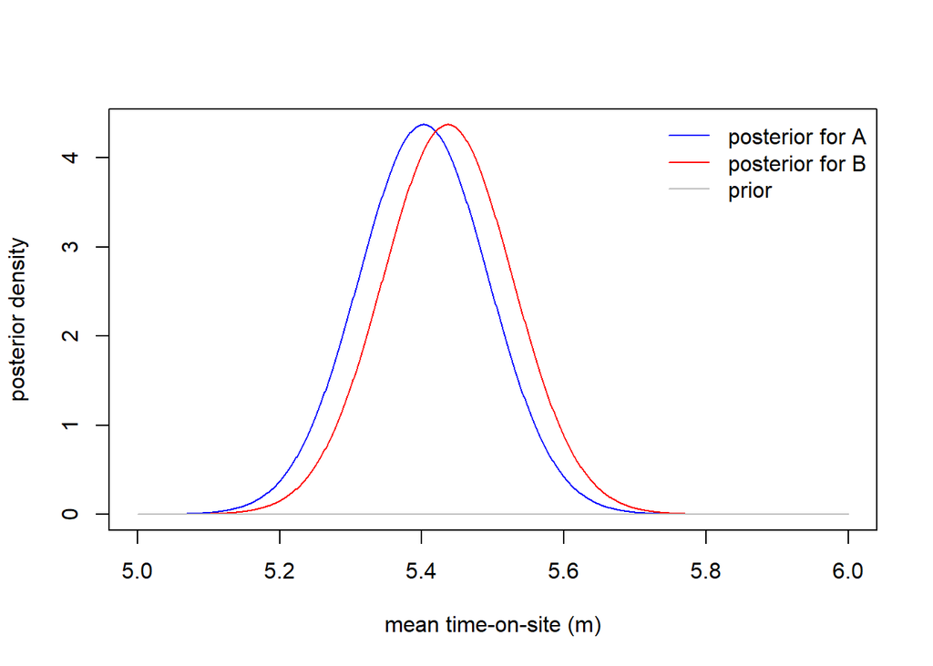

```r
xx=seq(5,6,length=1000)

plot(x=xx, y=dnorm(xx, mean=post_mean_A, sd=post_sd_A),
     type="l", col="blue", xlab="mean time-on-site (m)", ylab="posterior density")
lines(x=xx, y=dnorm(xx, mean=post_mean_B, sd=post_sd_B), col="red")
lines(x=xx, y=dnorm(xx, mean=0, sd=100), col="gray")
legend("topright", col=c("blue", "red", "gray"), legend=c("posterior for A", "posterior for B", "prior"), bty="n", lty=1)
```

Once we have the distribution for the difference in the mean time-on-site, we can compute the probability that the mean of B is greater than the mean of A.

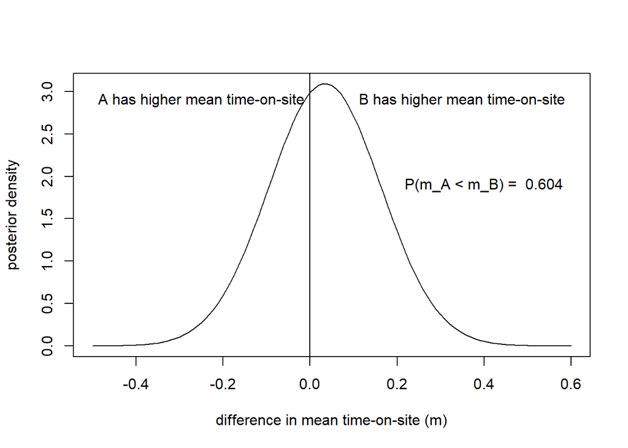

```r
post_mean_diff <- post_mean_B - post_mean_A
post_sd_diff <- sqrt(post_sd_B^2 + post_sd_A^2)
prob=1-pnorm(0, mean=post_mean_diff, sd=post_sd_diff)

plot(x=(-50:60)/100, y=dnorm((-50:60)/100, mean=post_mean_diff, sd=post_sd_diff),
     type="l", col="black",
     xlab="difference in mean time-on-site (m)", ylab="posterior density")
abline(v=0)
text(-0.25, 2.9, "A has higher mean time-on-site")
text(0.35, 2.9, "B has higher mean time-on-site")
text(x = .4,y= 1.9, paste("P(m_A < m_B) = ", round(prob,3) ))
```

There is a 95% probability that the average time-on-site for treatment A is:

```r
qnorm(c(0.025, 0.975), mean=post_mean_A, sd=post_sd_A) # CI for A
```

```
## [1] 5.223535 5.581252
```

There is a 95% probability that the average time-on-site for treatment B is:

```r
qnorm(c(0.025, 0.975), mean=post_mean_B, sd=post_sd_B) # CI for B
```

```
## [1] 5.257608 5.615326
```

# Test and Roll (code from Elea Feit)

*Test* Choose $n_1^*$ and $n_2^*$ customers to send the treatments.  
Collect data on profit for both treatments.

*Roll* Choose a treatment to deploy to the remaining $N - n_1^* - n_2^*$ customers.

*Objective* Maximize combined profit for test stage and the roll stage.

## Profit-maximizing sample size

If you have a test where the **profit** earned for each customer is:  
$y \sim \mathcal{N}(m_1, s)$ for group 1  
$y \sim \mathcal{N}(m_2, s)$ for group 2

and your priors are  
($m_1, m_1 \sim N(\mu, \sigma)$)

the profit maximizing sample size is:
$$n_1 = n_2 = \sqrt{\frac{N}{4}\left( \frac{s}{\sigma} \right)^2 + \left( \frac{3}{4} \left( \frac{s}{\sigma} \right)^2 \right)^2 } - \frac{3}{4} \left(\frac{s}{\sigma} \right)^2$$
This new sample size formula is derived in [Feit and Berman (2019) *Marketing Science*](https://papers.ssrn.com/sol3/papers.cfm?abstract_id=3274875).

## Compute the sample size in R

```r
source("nn_functions.R") # some functions I wrote
N <- 100000 # available population
mu <- 0.68  # average conversion rate across previous treatments
sigma <- 0.03 # range of expected conversation rates across previous treatments
s <- sqrt(mu*(1-mu)) # binomial approximation
test_size_nn(N=N, s=s, mu=mu, sigma=sigma) # compute the optimal test size
```

```
## [1] 2283.89 2283.89
```

## Why is this the profit-maximizing test size?

`test_eval_nn()` computes the profit of a Test & Roll.

```r
# Optimal test size
n_star <- test_size_nn(N=N, s=s, mu=mu, sigma=sigma)
test_eval_nn(n=n_star, N=N, s=s, mu=mu, sigma=sigma)
```

```
##        n1      n2 profit_per_cust profit profit_test profit_deploy profit_rand
## 1 2283.89 2283.89         0.69536  69536     3106.09      66429.91       68000
##   profit_perfect profit_gain      regret error_rate deploy_1_rate tie_rate
## 1       69692.57   0.9074956 0.002246583  0.1001281           0.5        0
```

## Why is this the profit-maximizing test size?

```r
# Bigger test
test_eval_nn(n=c(10000, 10000), N=N, s=s, mu=mu, sigma=sigma)
```

```
##      n1    n2 profit_per_cust   profit profit_test profit_deploy profit_rand
## 1 10000 10000       0.6933798 69337.98       13600      55737.98       68000
##   profit_perfect profit_gain      regret error_rate deploy_1_rate tie_rate
## 1       69692.57   0.7905008 0.005087943 0.04910146           0.5        0
```

```r
# Smaller test
test_eval_nn(n=c(100, 100), N=N, s=s, mu=mu, sigma=sigma)
```

```
##    n1  n2 profit_per_cust  profit profit_test profit_deploy profit_rand
## 1 100 100        0.689137 68913.7         136       68777.7       68000
##   profit_perfect profit_gain     regret error_rate deploy_1_rate tie_rate
## 1       69692.57    0.539832 0.01117574  0.3180785           0.5        0
```

## Why is this the profit-maximizing test size?

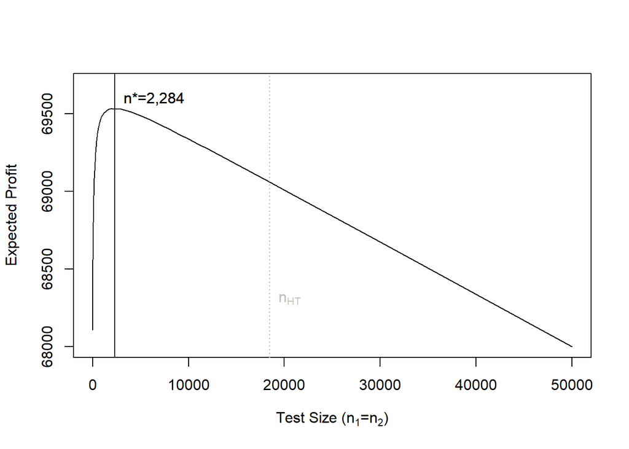

## How often do you deploy the wrong treatment?

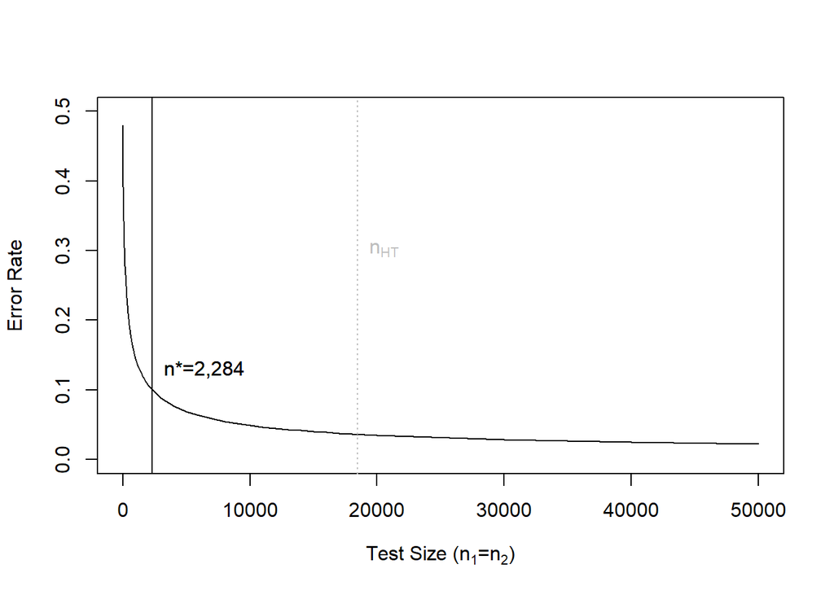

## Profit-maximizing sample size

The `test_size_nn()` function is making the optimal trade-off between:

- the opportunity cost of the test (You are sending the wrong treatment to half your customers!)

and

- the risk of deploying the wrong treatment

## How to choose `N`, `mu`, `sigma` and `s`

### What is `N`?

`N` is the total number of customers you have available, i.e. the size of your email mailing list or the the number of visits that might visit a webpage in the next month.

Let’s vary `N` and look at how the profit-maximizing test size changes:

```r
Ns <- (1:1000)*1000
test_sizes <- rep(NA, length(Ns))
for (i in 1:length(Ns))
  test_sizes[i] <- test_size_nn(N=Ns[i], s=s, mu=mu, sigma=sigma)[1]
```

```r
plot(x=Ns, y=test_sizes, type="l", col="orange",
     xlab="available population (N)", ylab="profit-maximizing sample size")
```

### What is `N`?

Bigger `N` $\rightarrow$ bigger test

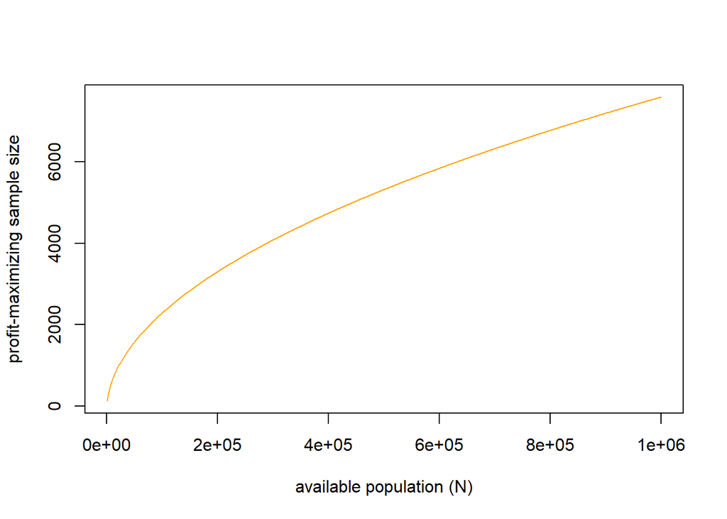

### What is `mu`?

`mu` is the average profit you expect across treatments you might test.

Let’s vary `mu`:

```r
mus <- (1:1000)/100
test_sizes <- rep(NA, length(mus))
for (i in 1:length(mus))
  test_sizes[i] <- test_size_nn(N=N, s=s, mu=mus[i], sigma=sigma)[1]
```

```r
plot(x=mus, y=test_sizes, type="l", col="orange",
     xlab="expected average profit per customer (mu)", ylab="profit-maximizing sample size")
```

### What is `mu`?

`mu` doesn’t effect the test size (when `mu` is the same for both A and B)

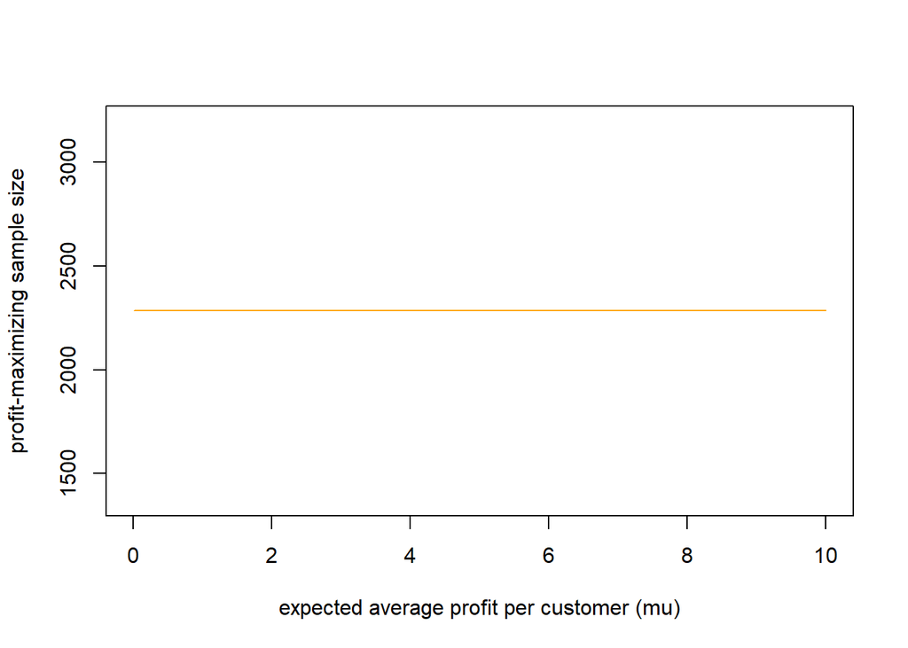

### What is `s`?

`s` is how variable the profit is from one customer to another.

Let’s vary `s`:

```r
ss <- (1:1000)/1000
test_sizes <- rep(NA, length(ss))
for (i in 1:length(ss))
  test_sizes[i] <- test_size_nn(N=N, s=ss[i], mu=mu, sigma=sigma)[1]
```

```r
plot(x=ss, y=test_sizes, type="l", col="orange",
     xlab="noise in profit per customer (s)", ylab="profit-maximizing sample size")
```

### What is `s`?

Bigger `s` $\rightarrow$ harder to see what is going on $\rightarrow$ bigger test

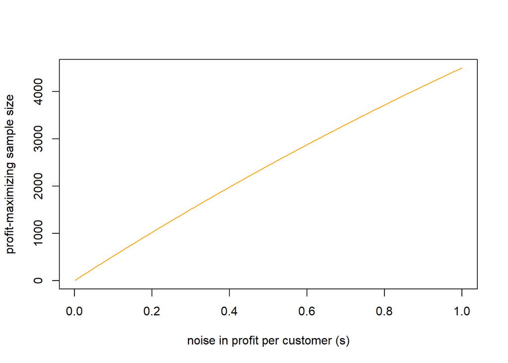

Hypothesis testing requires much bigger sample sizes (proportional to `s^2` instead of `s`).

### What is `sigma`?

`sigma` defines the difference we expect between average profit for the two treatments.

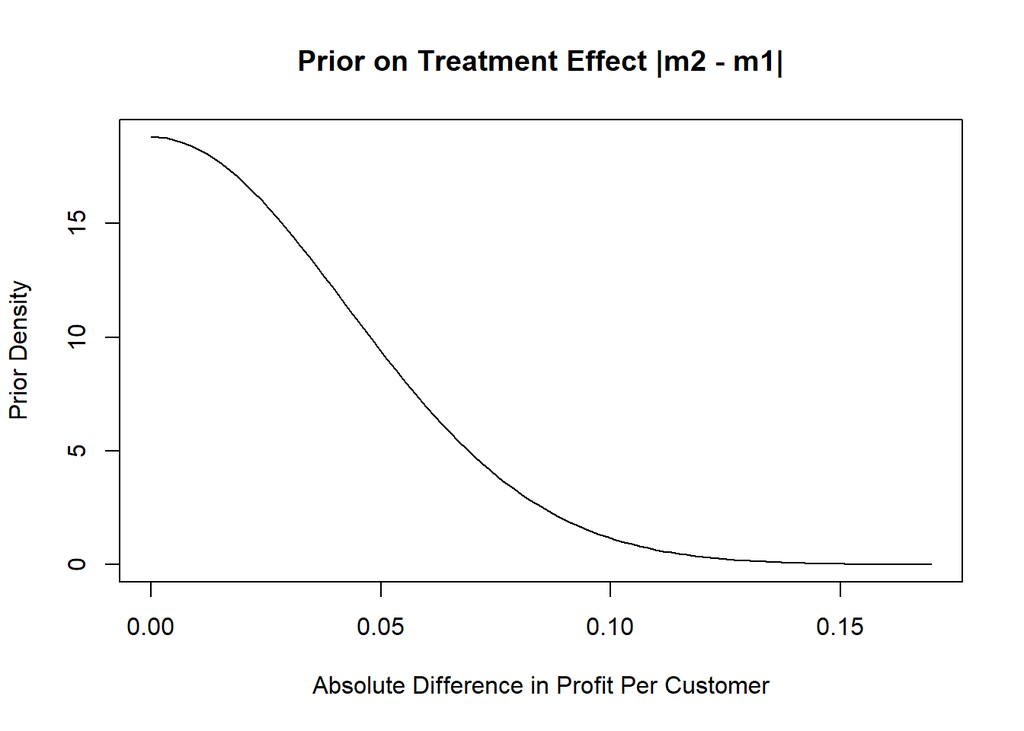

```r
plot_prior_effect_nn(mu, sigma, abs=TRUE)
```

### What is `sigma`?

Let’s vary `sigma`:

```r
sigmas <- (1:1000)/10000
test_sizes <- rep(NA, length(sigmas))
for (i in 1:length(sigmas))
  test_sizes[i] <- test_size_nn(N=N, s=s, mu=mu, sigma=sigmas[i])[1]
```

```r
plot(x=sigmas, y=test_sizes, type="l", col="orange",
     xlab="prior sd of treatment mean profit (sigma)", ylab="profit-maximizing sample size")
```

### What is `sigma`?

Bigger `sigma` $\rightarrow$ bigger difference between A and B $\rightarrow$ smaller test

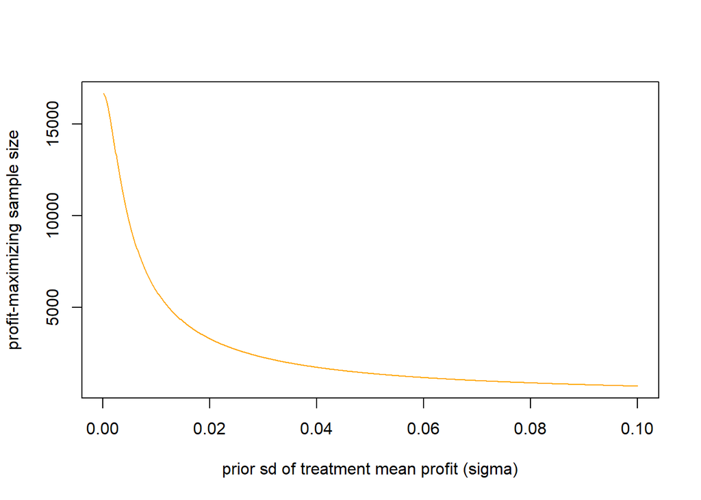

#### appendix

```r
# nonparametric bootstrap
n<-c(10, 100, 1000) # sample
B <- 500 # number of bootstrap samples
mub <- matrix(0, nrow = B, ncol = length(n)) # where we are going to collect the mean
set.seed(19312) # setting seed right before sampling



for (nn in 1:length(n)){
for (b in 1:B){
  samp_b = sample.int(nrow(ebeer), size = n[nn], replace=FALSE) # sample with replacement
  mub[b,nn] <- mean(ebeer$M[samp_b]) # store the mean of the sample
}
}
head(mub)  # the mean of the first few bootstrap samples
```

```
##           [,1]     [,2]     [,3]
## [1,]  82.34000 92.77102 90.82203
## [2,]  80.44365 96.44329 90.75627
## [3,] 105.93750 90.89701 94.68896
## [4,]  86.39464 84.69932 88.65778
## [5,]  89.73045 84.51551 95.75750
## [6,]  95.23762 91.21132 93.72626
```

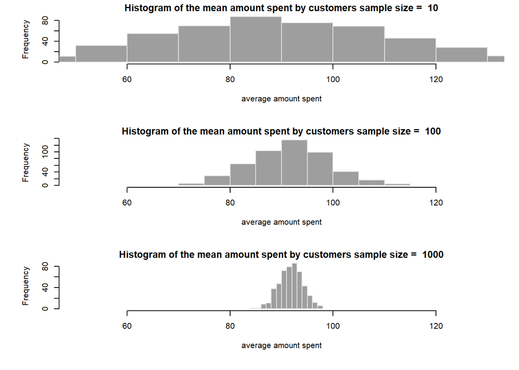

```r
mmean<-apply(mub, 2, mean)
sd<-apply(mub, 2, sd)  # standard deviation (compare with standard error xbse calculated above)

par(mfrow=c(3,1))
par(mai=c(.8,.8,.2,.2))
for (nn in 1:length(n)){

hist(mub[,nn], main=paste("Histogram of the mean amount spent by customers sample size = ", n[nn], sep=" "), xlab="average amount spent", xlim=c(50,130), col=8, border="grey90", freq=TRUE)
abline(v = mu)


}
```